# Lab_9

Mark Chafin

3/30/2021

# 1

Download Missouri S&T’s enrollment file “mst_enrollment2015.csv download” and read it into R.

```r
df <- read.csv("mst_enrollment2015.csv")
```

# 2

Show all the unique countries of MST students. (1 point) How many countries are there? (1 point)

```r
unique_countries <- unique(df$Country)
length(unique_countries)
```

```
## [1] 89
```

```r
# There are 89 unique countries
```

# 3

Then let’s focus on domestic students and use dplyr::filter() to select students come from the US. (2 point)

```r
df <- df[-1]
df <- df %>% filter(Country == "United States")
```

# 4

Use tidyr:: gather to reshape the dataset by transforming it from wide format to long format, using “Year” as key and “Enroll” as value. (2 points)

```r
df <- df %>% gather(Year, Enroll ,c(X2011,X2012,X2013,X2014,X2015))
df
```

| Country | State | Year | Enroll |
| --- | --- | --- | --- |
| United States | Armed Forces Europe | X2011 | 2 |
| United States | Armed Forces Pacific | X2011 | 1 |
| United States | Alabama | X2011 | 11 |
| United States | Alaska | X2011 | 11 |
| United States | Arizona | X2011 | 20 |
| United States | Arkansas | X2011 | 55 |
| United States | California | X2011 | 62 |
| United States | Colorado | X2011 | 37 |
| United States | Connecticut | X2011 | 4 |
| United States | Delaware | X2011 | 6 |

[output cut: 255 more lines]

# 5

Use dplyr::group_by to aggregate enrollment data into state level, i.e. calculate total enrollment for each state. (2 points)

```r
df <- df %>% group_by(State) %>% summarise(Total_Enroll = sum(Enroll))

df
```

| State | Total_Enroll |
| --- | --- |
| Alabama | 76 |
| Alaska | 42 |
| Arizona | 105 |
| Arkansas | 229 |
| Armed Forces Europe | 3 |
| Armed Forces Pacific | 4 |
| California | 276 |
| Colorado | 193 |
| Connecticut | 13 |
| Delaware | 22 |

[output cut: 43 more lines]

# 6

Since our task is to plot out-of-state enrollment, use dplyr::filter() to remove enrollment data of Missouri (in-state enrollment). (2 point)

```r
df <- df %>% filter(State != "Missouri")
```

# 7

Show the top 6 states from which the out-of-state students come and their corresponding enrollment number. (2 points)

```r
df <- arrange(df,-Total_Enroll)
head(df)
```

| State | Total_Enroll |
| --- | --- |
| Illinois | 2532 |
| Texas | 697 |
| Kansas | 621 |
| California | 276 |
| Washington | 270 |
| Oklahoma | 267 |

# 8

Use ggplot2 package to draw the MST’s out-of-state enrollment on the US states map. (6 points)

```r
us_states <- map_data("state")
str(us_states)
```

```
## 'data.frame':    15537 obs. of  6 variables:
##  $ long     : num  -87.5 -87.5 -87.5 -87.5 -87.6 ...
##  $ lat      : num  30.4 30.4 30.4 30.3 30.3 ...
##  $ group    : num  1 1 1 1 1 1 1 1 1 1 ...
##  $ order    : int  1 2 3 4 5 6 7 8 9 10 ...
##  $ region   : chr  "alabama" "alabama" "alabama" "alabama" ...
##  $ subregion: chr  NA NA NA NA ...
```

```r
map_state <- unique(us_states$region)
df$Region <- tolower(df$State)
setdiff(df$Region,map_state)
```

```
## [1] "alaska"               "hawaii"               "armed forces pacific"
## [4] "armed forces europe"
```

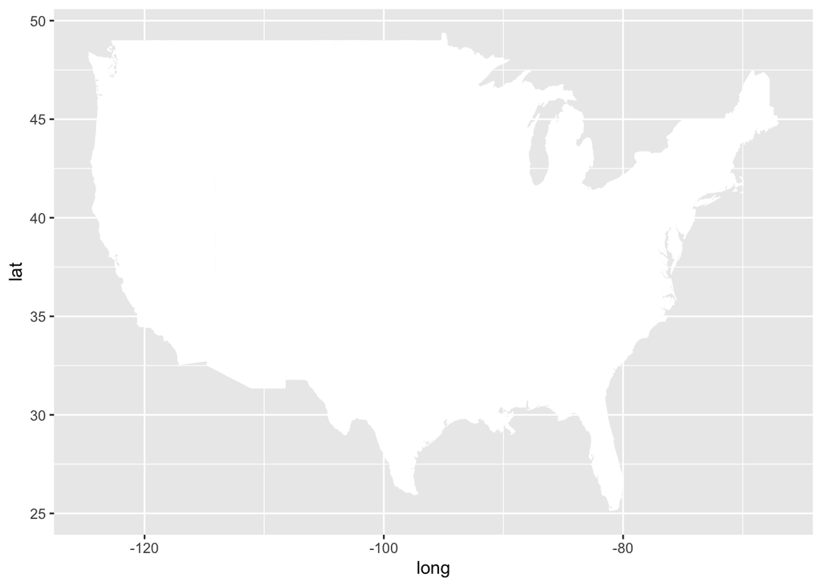

```r
gg <- ggplot()
gg <- gg + geom_map(data = us_states, map = us_states,
                    aes(x = long, y = lat, map_id = region),
                    fill="#ffffff", color="#ffffff", size=0.15)

gg
```

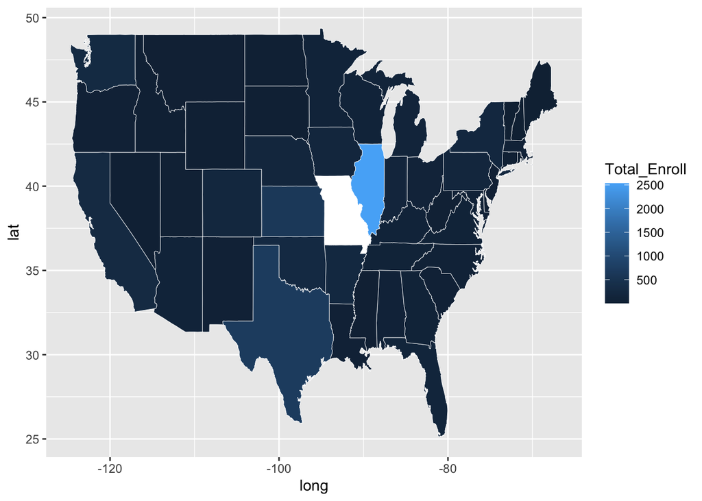

```r
gg <- gg + geom_map(data=df, map = us_states,
                    aes(fill=Total_Enroll, map_id=Region),
                    color="#ffffff", size=0.15)
gg
```

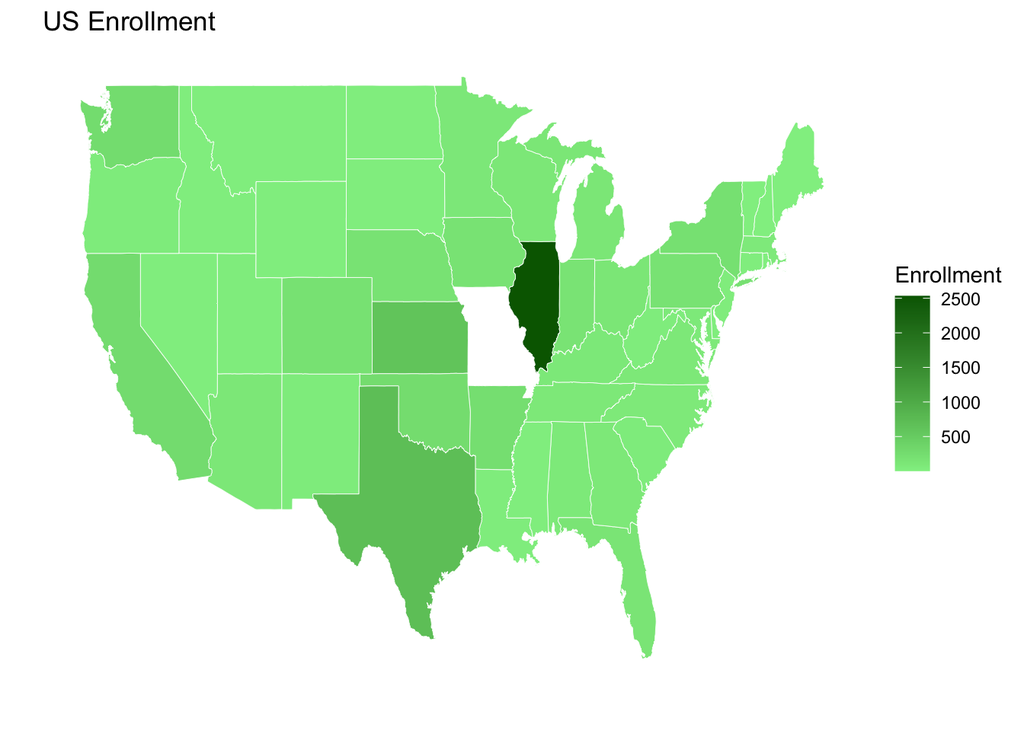

```r
gg <- gg + scale_fill_continuous(low = "lightgreen", high= "darkgreen",
                                 guide="colorbar")
gg <- gg + labs(fill = "Enrollment",
                title = "US Enrollment",
                x = "", y="")

gg <- gg + theme(panel.border = element_blank())
gg <- gg + theme(panel.background = element_blank())
gg <- gg + theme(axis.ticks = element_blank())
gg <- gg + theme(axis.text = element_blank())

gg
```

# 9

Knit your R Markdown file into an HTML file and upload both R Markdown file and associated HTML file to Canvas (2pts).